# Test_1

```r
library(psych)
library(tidyverse)
library(haven)
library(magrittr)
library(MASS)
library(vcd)
library(caret)
library(tidyr)
```

First we import the data files into our R session. Given that they are .sav files we can use the read_spss function from the haven package.

```r
delinquency.dat <- read_spss("Cambridge_delinquency.sav")
convict.dat <- read_spss("conviction_data.sav")
```

An initial look at the data-sets shows that the delinquency data comprises 870 variables, with 411 observations, each observation corresponding to an individual (suppressed large output due to space). Variables are not appropriately named; once we identify a set of predictors of interest we will rename them to give them meaning. In the conviction data-set, we find 3 variables allocating the identity number, age and whether or not the person was convicted of a crime.

A brief look through the convict.dat data-set shows the convictions of the boys at different stages of life. Information for 411 are given at 7 different time points, totalling the 2877 observations. We will need to convert this to a wide format in order to join it the delinquency data above.

```r
summary(convict.dat)
```

```
##  icpsr_seq_id_number    agecat            convicted
##  Min.   :  1         Length:2877        Min.   :1.000
##  1st Qu.:103         Class :character   1st Qu.:1.000
##  Median :206         Mode  :character   Median :1.000
##  Mean   :206                            Mean   :1.205
##  3rd Qu.:309                            3rd Qu.:1.000
##  Max.   :411                            Max.   :2.000
##                                         NA's   :48
```

Selection of Variables:

For the present project, I wish to investigate what the potential behavioural risk factors are for pre-adolescent boys. I will choose to focus on the early predictors of boys between the ages of 8-12, since I am interested in seeing how well we can predict later criminality based on data collected at such a young age. Pre-adolescents have not even begun to develop their identities as individuals and thus by evaluating early risk factors for criminality, we can aim to implement intervention programmes at a critical period in the child’s life in the hope that we may be able prevent a life of crime

In accordance with the overall aim set out above, I will investigate how behavioural tendencies can be indicative of later criminal offenders in a pre-adolescent group from England. Variables will be largely drawn from the 10-11 age group, but also from the 8-9 age group. Where possible, when two measures were taken in both the 8-9 and 10-11 age group, we use the “combined” variables, which represent the average of those two scores across the groups.

Variables of interest

Historical/Background Variables

Family history of criminality: 300 CRIMINAL RECORD OF PARENTS 301 DELINQUENT OLDER SIBLINGS

Socio-economic status: 92 INCOME OF FAMILY

Family factors: 69 FAMILY SIZE 134 BROKEN HOME BEFORE AGE 10

Parenting style: 123 PHYSICAL NEGLECT OF BOY 180 AUTHORITARIANISM OF PARENTS COMBINED

Behavioural and School Measures

Behavioural characteristics: 108 OBEDIENCE OF BOY 195 DARING OF BOY COMBINED 237 NERVOUSNESS OF BOY COMBINED 277 TROUBLESOMENESS OF BOY COMBINED 279 TEACHER RATING: COMBINED

Intelligence and School perforamnce 310 JUNIOR SCHOOL LEAVING RESULTS 254 PROGRESSIVE MATRICES IQ COMBINED 283 VERBAL IQ COMBINED

First we exclude variables and only include the 15 variables that we are interested in modelling and give the variables meaningful names using the pipe command and dplyr package.

```r
delinqreduced <- delinquency.dat %>%
  dplyr::select(v300, v301, v92, v69, v134, v123, v180, v108, v195, v237, v277, v279, v310, v254, v283) %>% #selects variables
  rename(crimrec_parents = v300, delinq_siblings = v301, family_income = v92, family_size = v69, broken_home = v134, physical_neglect = v123, authoratarianism_style = v180 , obedience_boy = v108, daringness_boy = v195, nervousness_boy =  v237, troublesomeness = v277, teacher_rating_naughty = v279, school_results = v310, nonverbal_IQ = v254, verbal_IQ = v283) #renames each variable
```

To see whether we successfully selected and renamed varibles of interest, we use the str command to have a look through the variables to see if they correspond to labels. I see that they do; I have chosen to suppress this input as it is unnecessary and will take up space.

Joining the two data-sets

We need to get a matching variable in order to join the two data-sets we have. Since the row-numbers correspond to the participants 1-411, we can use the add_rownames command in dplyr to create our matching variable.

```r
delinqreduced <- add_rownames(delinqreduced, "icpsr_seq_id_number")
```

Next, we will transform the conviction data into wide, suitable for joining, and then we will merge the two data-sets into one.

```r
wideconvict.dat <- convict.dat %>%
  spread(key = agecat, value = convicted) #create a wide version of conviction data, such that we have 411 rows.

wideconvict.dat$icpsr_seq_id_number <- as.character(wideconvict.dat$icpsr_seq_id_number) #change to character vector suitable for join

crime.dat <- left_join(delinqreduced, wideconvict.dat, by = "icpsr_seq_id_number") #create new composite data-set

crime.dat %<>% drop_na() #drop cases with NA values for appropriate lda analysis. Since we have a sufficiently large sample, I will drop these listwise.
```

Now that we have suitable set-up our data, we can now move forward and explore it.

Question 2: Exploring the data-set

Before conducting an exploration, I first would like to convert the 1’s and 2’s for conviction data into 0’s and 1’s for ease of use. I use a simple for loop to do this by minusing one from each of the conviction columns.

```r
for (i in 17:23) { #shuffle through conviction columns
  crime.dat[,i] <- crime.dat[,i] - 1  #take off 1 for each value, i.e. 2 -> 1 and 1 -> 0
}
```

Now that we have our columns suitable set-up in terms of 0’s and 1’s, we can conduct an inital exploration. In our data-set we are providede with information about convictions at various ages, as well as grouped as either a juvenile (10 - 16) or an adult (17 - 24); however, we are not provided with an overall measure of whether the person was convicted at all (i.e. either at juvenile or adult), or not at all. Given that we have 0’s and 1’s, we can easily create such a variable by evaluating whether the juvenile and adult conviction columns sum to more than 0 (i.e. 1 in either column indicates a conviction) This will be the statistic we use in order to explore the data-set.

```r
crime.dat$convicted <- as.numeric((crime.dat$convicted_as_juvenile + crime.dat$convicted_as_adult) > 0)
```

We next convert the atomic vectors of our data-frame into a format suitable for models. We do this by unlisting them and convertin them to numeric values.

```r
for (i in 1:16) {
  crime.dat[,i] <- as.numeric(unlist(crime.dat[,i]))
}
```

We will initially explore the variables that we apriori hypothesise to be associated with later criminality in pre-adolescents.

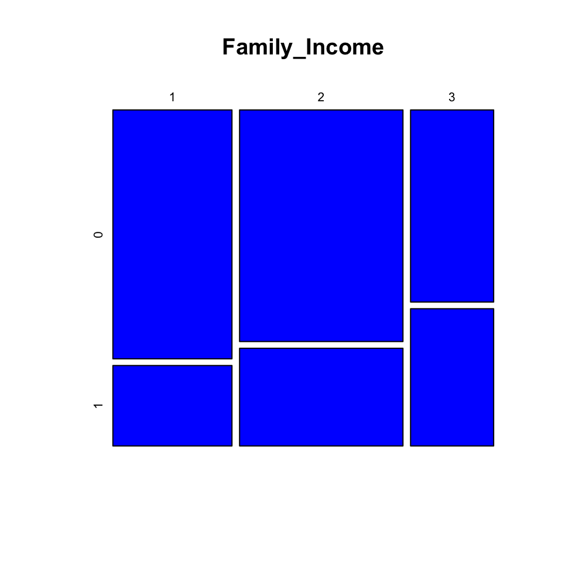

```r
Family_Income <- table(crime.dat$family_income, crime.dat$convicted)
Broken_Home <- table(crime.dat$broken_home, crime.dat$convicted)
mosaicplot(Family_Income, color = "blue")
```

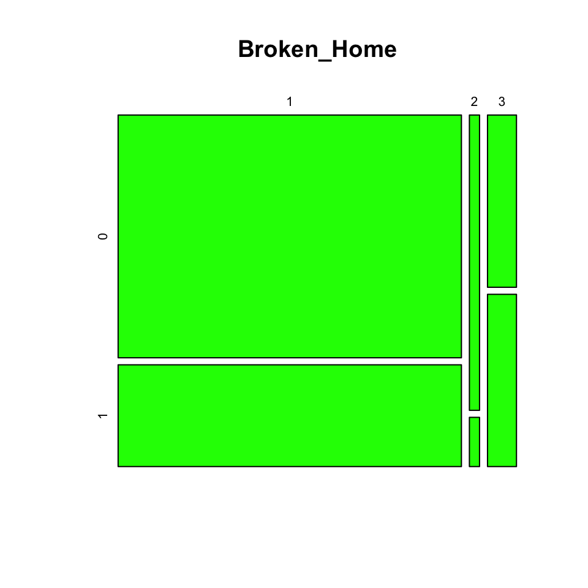

```r
mosaicplot(Broken_Home, color = "green")
```

Family History of Criminality

Next we explore whether a family history of crime is related to committing crimes. We investigate whether a parental record is related to commiting crimes, as well as sibling delinquency.

Parental Record

When evaluated, we find quite a strong relationship present, such that the more crimes a child’s parents has been convicted of as an adult, the more likely they are to commit a crime and be convicted themselves. Interestingly, it seems that being convicted as a juvenile only seems to be a better indicator of conviction than up to three convictions as an adult. In a similar fashion to parental record we find that a higher proportion of boys with convicted siblings are also more likely to later be convicted themselves (2 signifies the presence of sibling conviction, while 1 is the relative absence).

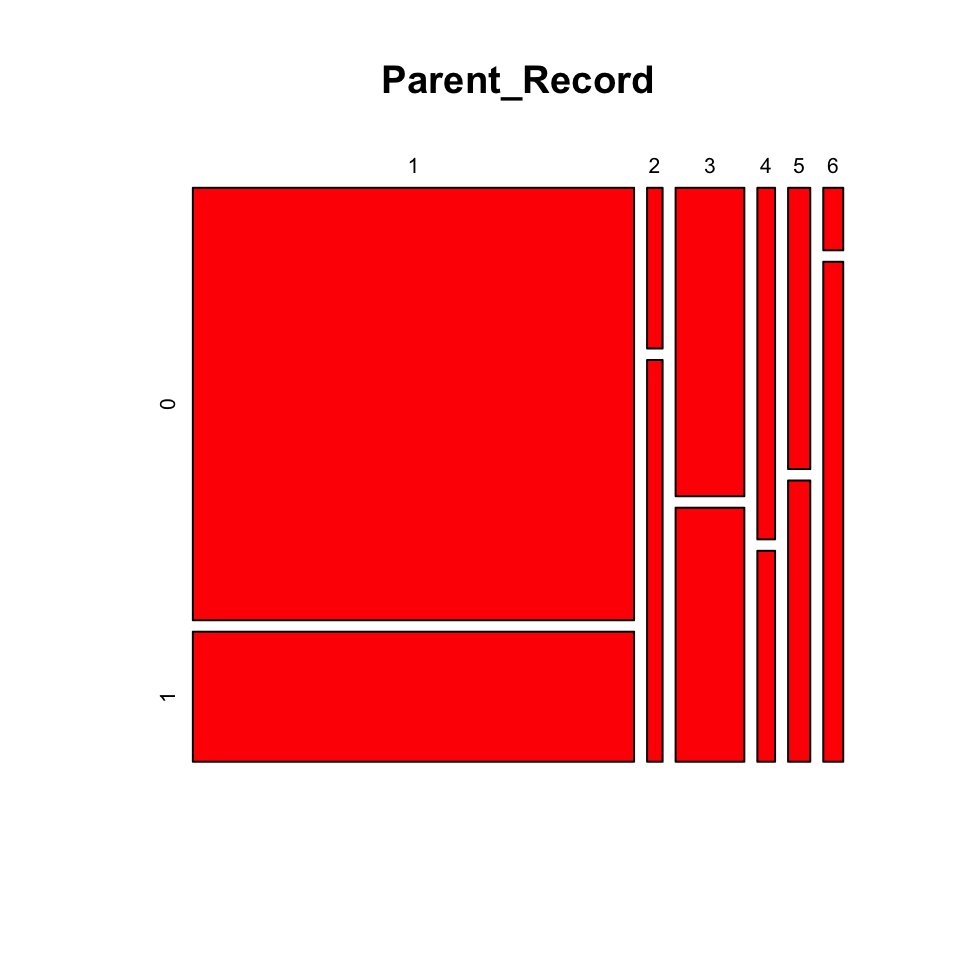

```r
Parent_Record <- table(crime.dat$crimrec_parents, crime.dat$convicted)
Sibling_Delinquency <- table(crime.dat$delinq_siblings, crime.dat$convicted)
mosaicplot(Parent_Record, color = "red")
```

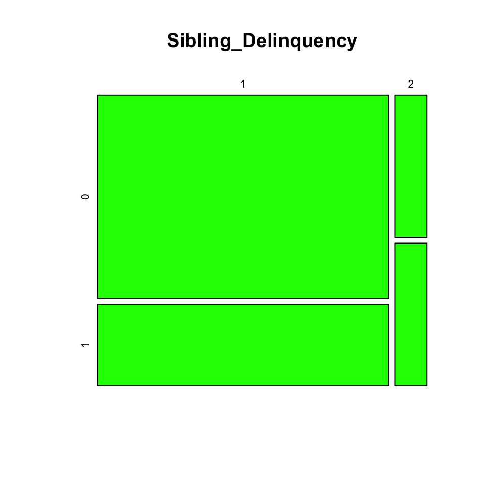

```r
mosaicplot(Sibling_Delinquency, color = "green")
```

Parenting (Physical Neglect and Authoritarianism)

Using a mosaic plot to look at physical neglect, we find a higher proportion of boys who were physically neglected to go on to be convictec of crimes, indicated by the relatively larger rectangle in the bottom-right corner compare to the top-left. A more sever authoritarian style also seems to be associated with a higher probability of convictions.

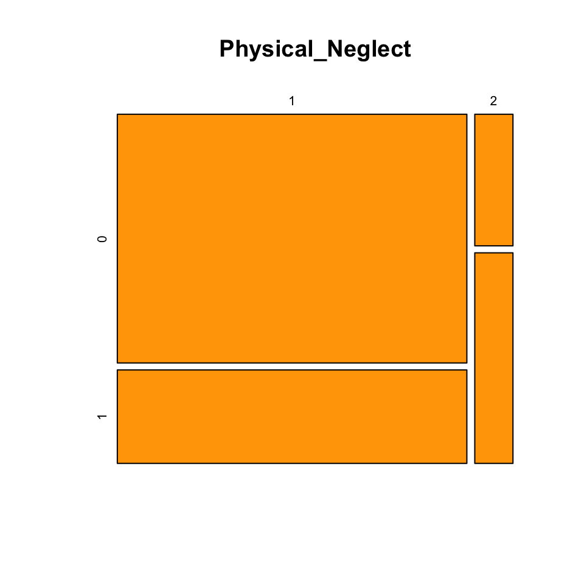

```r
Physical_Neglect <- table(crime.dat$physical_neglect, crime.dat$convicted)
Authoritarianism <- table(crime.dat$authoratarianism_style, crime.dat$convicted)
mosaicplot(Physical_Neglect, color = "orange")
```

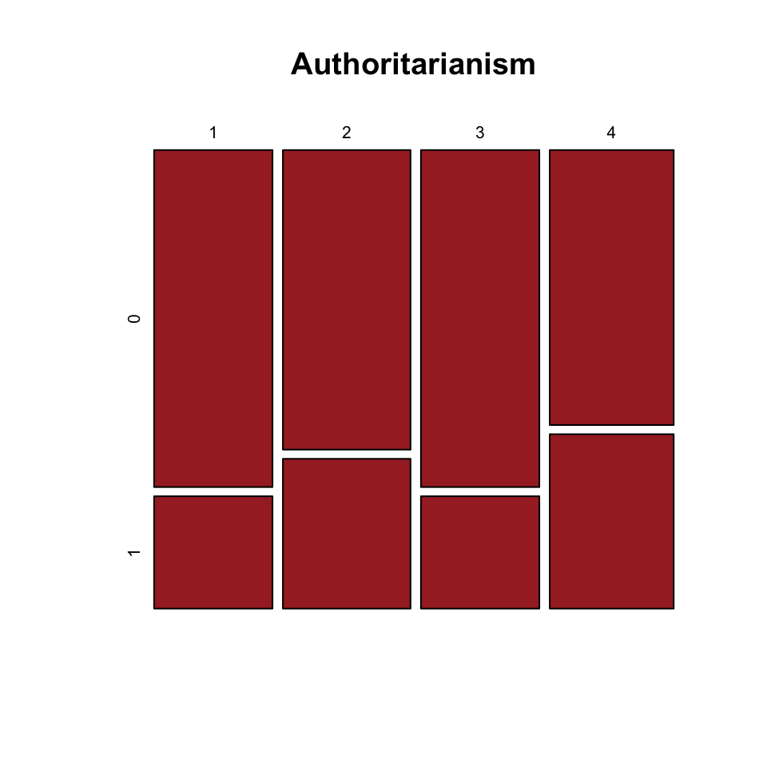

```r
mosaicplot(Authoritarianism, color = "brown")
```

Family Factors

For other familial factors, we look family size, since this one a main finding found in the Krohn (2006) review of key findings. As in the report, we find that a larger family tends to be associated with more convictions.

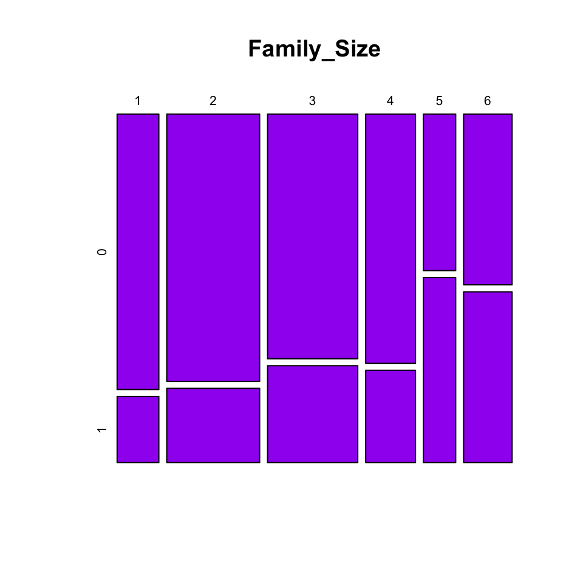

```r
Family_Size <- table(crime.dat$family_size, crime.dat$convicted)
Broken_Home <- table(crime.dat$broken_home, crime.dat$convicted)
mosaicplot(Family_Size, color = "purple")
```

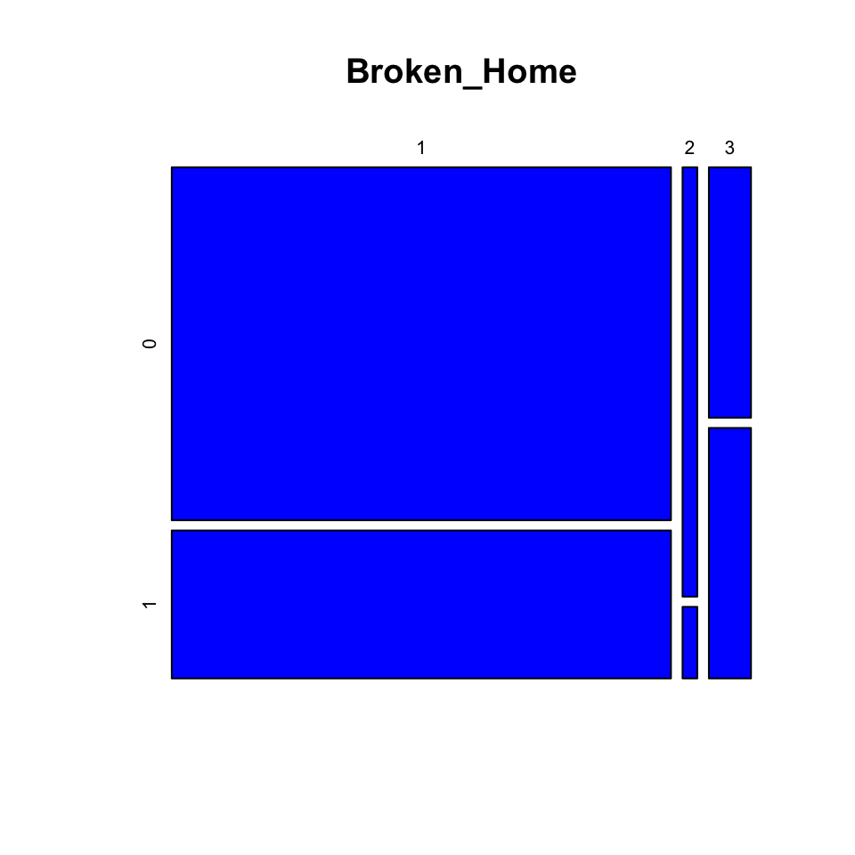

```r
mosaicplot(Broken_Home, color = "blue")
```

Behavioural Measures

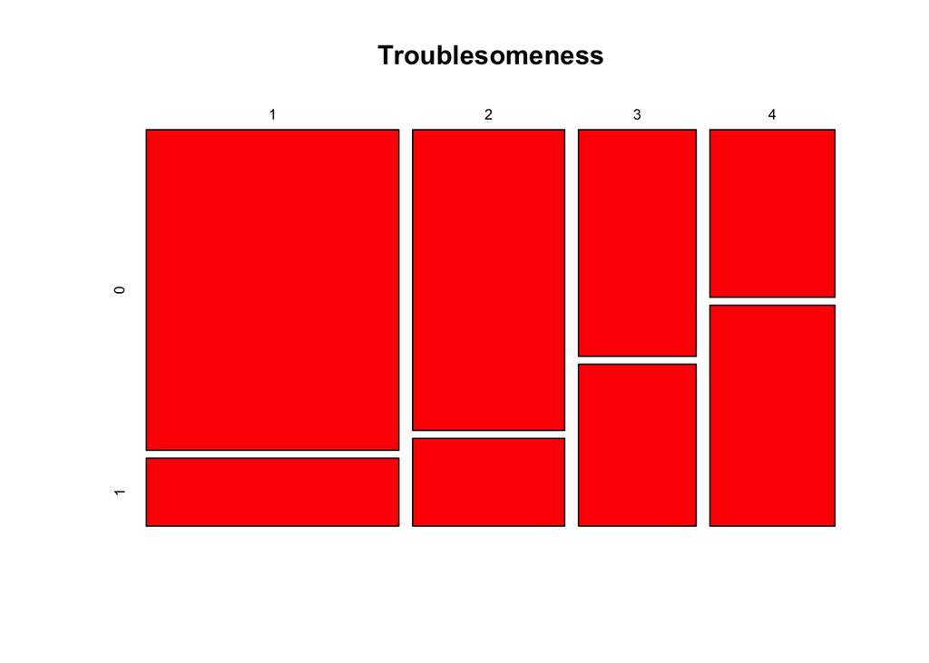

```r
Troublesomeness <- table(crime.dat$troublesomeness, crime.dat$convicted)
Obedience <- table(crime.dat$obedience_boy, crime.dat$convicted)
Daringness <- table(crime.dat$daringness_boy, crime.dat$convicted)
Nervousness <- table(crime.dat$nervousness_boy, crime.dat$convicted)
Teacher_Rating_Naughty <- table(crime.dat$teacher_rating_naughty, crime.dat$convicted)
mosaicplot(Troublesomeness, color = "red")
```

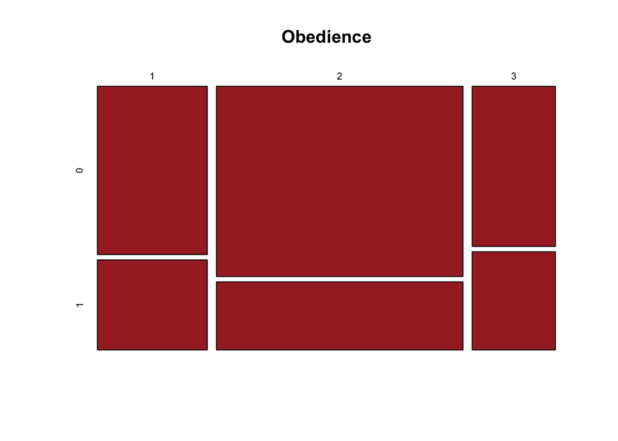

```r
mosaicplot(Obedience, color = "brown")
```

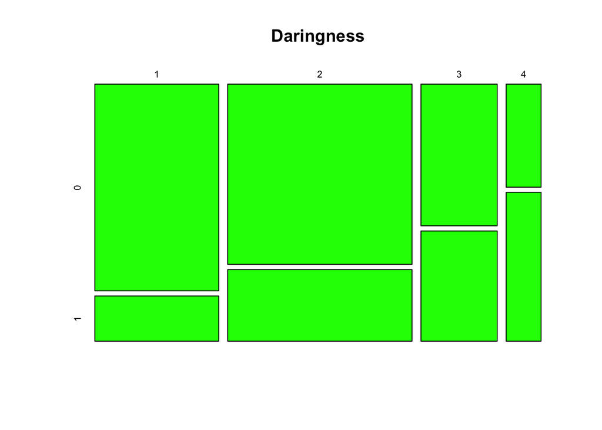

```r
mosaicplot(Daringness, color = "green")
```

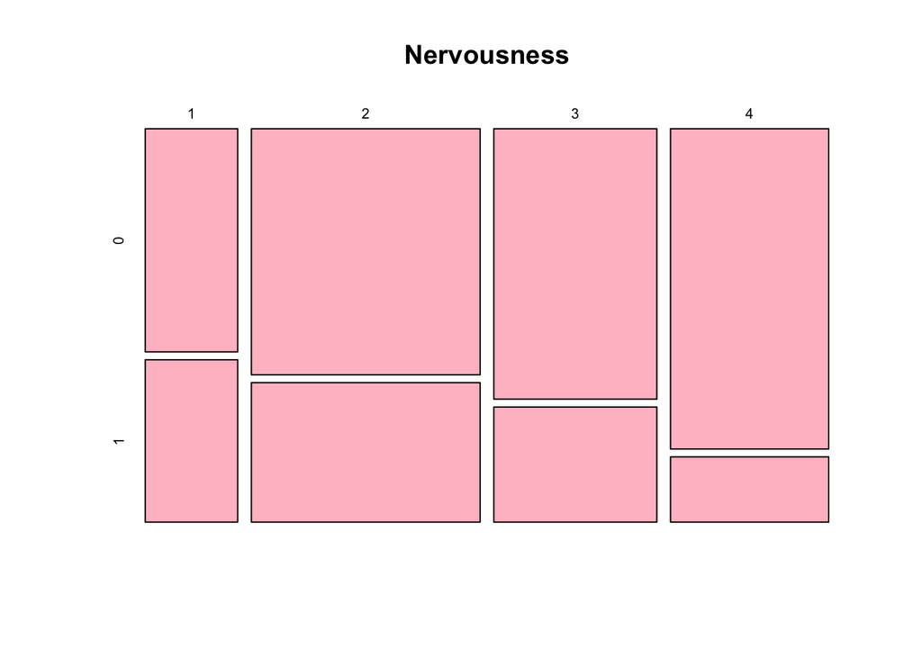

```r
mosaicplot(Nervousness, color = "pink")
```

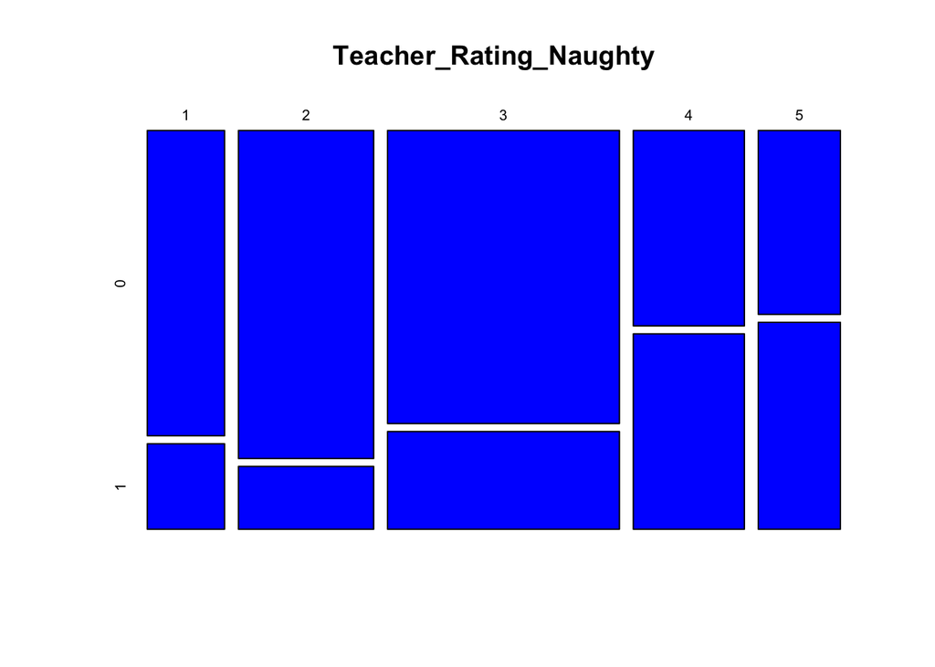

```r
mosaicplot(Teacher_Rating_Naughty, color = "blue")
```

Intelligence and School Performance

Finally we have a look at the relationship between measures of intelligence (verbal and non-verbal IQ) and general shcool performance (grades) on convictions. From all mosaic plots below there does seem to be a slight relationshp present whereby children with more general intelligence (be it verbal or non-verbal) and who get better marks tend to be less likley to be convicted later in life. Once again we should bear in mind that these measures might well be related to one’s familial background and thus it is not clear whether these variables will add in more explanatory power to a model containing variables related to one’s background.

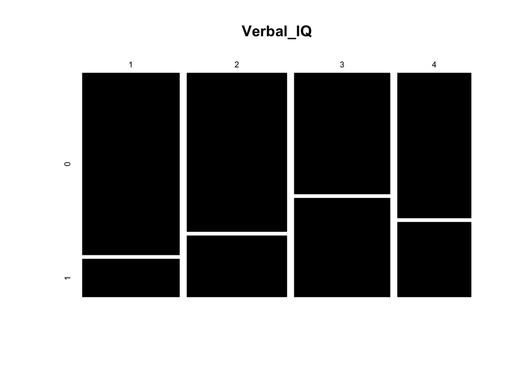

```r
Verbal_IQ <- table(crime.dat$verbal_IQ, crime.dat$convicted)
Non_Verbal_IQ <- table(crime.dat$nonverbal_IQ, crime.dat$convicted)
School_Results <- table(crime.dat$school_results, crime.dat$convicted)
mosaicplot(Verbal_IQ, color = "black")
```

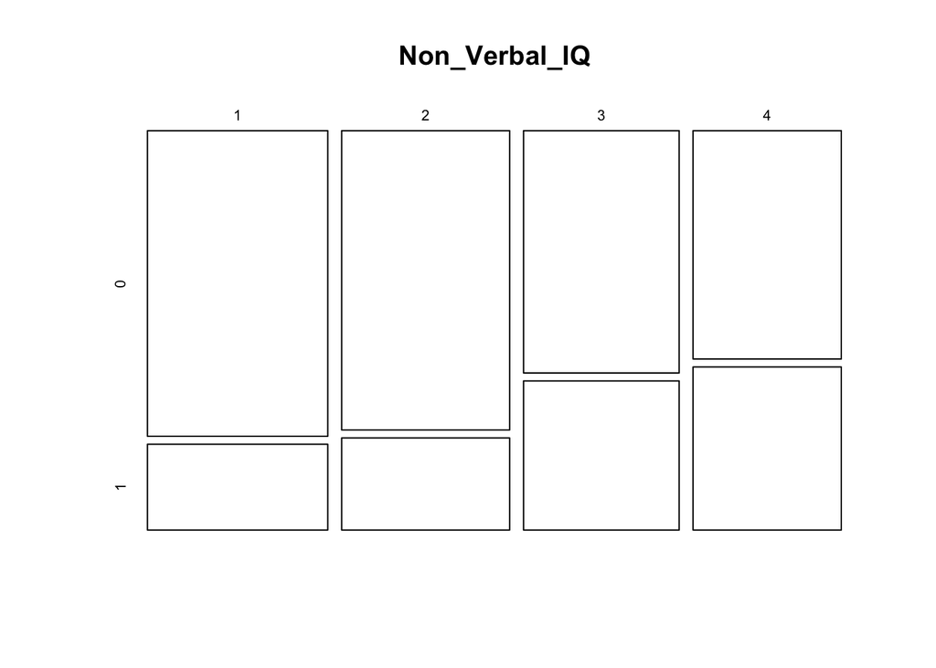

```r
mosaicplot(Non_Verbal_IQ, color = "white")
```

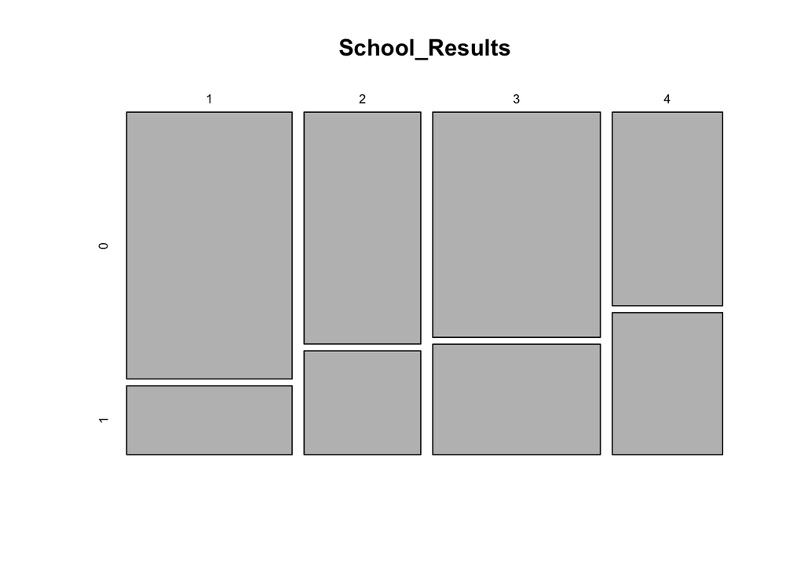

```r
mosaicplot(School_Results, color = "grey")
```

Question 3

We now move on to the hypothesis testing phase of our analysis. To recap, we are interested in evaluating whether school-related behaviour and performance can add any explanatory power beyond one’s family background in predicting whether someone will be convicted of a crime later in life. Given that we are interested in answering apriori hypotheses related to our data-set, I will use a hierarchical model in order to specify the variables of interest in respective model comparison. Given that we converted convictions into a binary variable (0 - not convicted, 1 - convicted), we will need to model a binomial outcome.

Linear Discriminant Analysis

```r
convicted_lda1 <- lda(convicted ~ crimrec_parents + delinq_siblings + family_income + family_size + broken_home + physical_neglect + authoratarianism_style, data = crime.dat)

convicted_lda1
```

```
## Call:
## lda(convicted ~ crimrec_parents + delinq_siblings + family_income +
##     family_size + broken_home + physical_neglect + authoratarianism_style,
##     data = crime.dat)
##
## Prior probabilities of groups:
##         0         1
## 0.6931818 0.3068182
##
## Group means:
##   crimrec_parents delinq_siblings family_income family_size broken_home
## 0        1.415301        1.071038      1.836066    2.994536    1.142077
## 1        2.259259        1.160494      2.049383    3.777778    1.259259
##   physical_neglect authoratarianism_style
## 0         1.054645               2.448087
## 1         1.197531               2.641975
##
## Coefficients of linear discriminants:
##                                LD1
## crimrec_parents         0.50358901
## delinq_siblings         0.58794781
## family_income          -0.14492316
## family_size             0.20466960
## broken_home             0.71158268
## physical_neglect        1.16859586
## authoratarianism_style  0.07503404
```

```r
predlda1 <- suppressWarnings(predict(convicted_lda1, crime.dat))
confusionMatrix(as.factor(predlda1$class), as.factor(crime.dat$convicted), positive = "1")
```

```
## Confusion Matrix and Statistics
##
##           Reference
## Prediction   0   1
##          0 170  60
##          1  13  21
##
##                Accuracy : 0.7235
##                  95% CI : (0.6653, 0.7766)
##     No Information Rate : 0.6932
##     P-Value [Acc > NIR] : 0.1584
##
##                   Kappa : 0.2245
##  Mcnemar's Test P-Value : 7.289e-08
##
##             Sensitivity : 0.25926
##             Specificity : 0.92896
##          Pos Pred Value : 0.61765
##          Neg Pred Value : 0.73913
##              Prevalence : 0.30682
##          Detection Rate : 0.07955
##    Detection Prevalence : 0.12879
##       Balanced Accuracy : 0.59411
##
##        'Positive' Class : 1
##
```

```r
convictselect <- crime.dat %>% #only select variables of interest
  dplyr::select(crimrec_parents, delinq_siblings, family_income, family_size, broken_home, physical_neglect, authoratarianism_style)
convictselect <- as.matrix(convictselect) #convert to matrix

summary(manova(convictselect ~ crime.dat$convicted), test = "Wilks") #Wilk test of significance.
```

```
##                      Df   Wilks approx F num Df den Df    Pr(>F)
## crime.dat$convicted   1 0.85991   5.9581      7    256 1.946e-06 ***
## Residuals           262
## ---
## Signif. codes:  0 '***' 0.001 '**' 0.01 '*' 0.05 '.' 0.1 ' ' 1
```

Adding behavioural variables to model

```r
convicted_lda2 <- lda(convicted ~ crimrec_parents + delinq_siblings + family_income + family_size + broken_home + physical_neglect + authoratarianism_style + obedience_boy + daringness_boy + nervousness_boy + troublesomeness + teacher_rating_naughty, data = crime.dat)
convicted_lda2
```

```
## Call:
## lda(convicted ~ crimrec_parents + delinq_siblings + family_income +
##     family_size + broken_home + physical_neglect + authoratarianism_style +
##     obedience_boy + daringness_boy + nervousness_boy + troublesomeness +
##     teacher_rating_naughty, data = crime.dat)
##
## Prior probabilities of groups:
##         0         1
## 0.6931818 0.3068182
##
## Group means:
##   crimrec_parents delinq_siblings family_income family_size broken_home
## 0        1.415301        1.071038      1.836066    2.994536    1.142077
## 1        2.259259        1.160494      2.049383    3.777778    1.259259
##   physical_neglect authoratarianism_style obedience_boy daringness_boy
## 0         1.054645               2.448087      1.934426       1.896175
## 1         1.197531               2.641975      1.950617       2.407407
##   nervousness_boy troublesomeness teacher_rating_naughty
## 0        2.726776        1.928962               2.770492
## 1        2.320988        2.740741               3.444444
##
## Coefficients of linear discriminants:
##                                LD1
## crimrec_parents         0.33241108
## delinq_siblings         0.46170638
## family_income          -0.16002919
## family_size             0.10464034
## broken_home             0.36595057
## physical_neglect        0.82522866
## authoratarianism_style -0.02064103
## obedience_boy           0.28284814
## daringness_boy          0.27565195
## nervousness_boy        -0.31604671
## troublesomeness         0.44861556
## teacher_rating_naughty -0.00102529
```

```r
suppressWarnings(predlda2 <- predict(convicted_lda2, newdata = crime.dat))
confusionMatrix(as.factor(predlda2$class), as.factor(crime.dat$convicted), positive = "1")
```

```
## Confusion Matrix and Statistics
##
##           Reference
## Prediction   0   1
##          0 171  43
##          1  12  38
##
##                Accuracy : 0.7917
##                  95% CI : (0.7376, 0.839)
##     No Information Rate : 0.6932
##     P-Value [Acc > NIR] : 0.000219
##
##                   Kappa : 0.4517
##  Mcnemar's Test P-Value : 5.228e-05
##
##             Sensitivity : 0.4691
##             Specificity : 0.9344
##          Pos Pred Value : 0.7600
##          Neg Pred Value : 0.7991
##              Prevalence : 0.3068
##          Detection Rate : 0.1439
##    Detection Prevalence : 0.1894
##       Balanced Accuracy : 0.7018
##
##        'Positive' Class : 1
##
```

```r
convictselect <- crime.dat %>% #only select variables of interest
  dplyr::select(crimrec_parents, delinq_siblings, family_income, family_size, broken_home, physical_neglect, authoratarianism_style, obedience_boy, daringness_boy, nervousness_boy, troublesomeness, teacher_rating_naughty)
convictselect <- as.matrix(convictselect) #convert to matrix

summary(manova(convictselect ~ crime.dat$convicted), test = "Wilks") #Wilk test of significance.
```

```
##                      Df   Wilks approx F num Df den Df    Pr(>F)
## crime.dat$convicted   1 0.77507   6.0702     12    251 2.507e-09 ***
## Residuals           262
## ---
## Signif. codes:  0 '***' 0.001 '**' 0.01 '*' 0.05 '.' 0.1 ' ' 1
```

Adding measures of intelligence and academic performance

```r
convicted_lda3 <- lda(convicted ~ crimrec_parents + delinq_siblings + family_income + family_size + broken_home + physical_neglect + authoratarianism_style + verbal_IQ + nonverbal_IQ + school_results, data = crime.dat)
convicted_lda3
```

```
## Call:
## lda(convicted ~ crimrec_parents + delinq_siblings + family_income +
##     family_size + broken_home + physical_neglect + authoratarianism_style +
##     verbal_IQ + nonverbal_IQ + school_results, data = crime.dat)
##
## Prior probabilities of groups:
##         0         1
## 0.6931818 0.3068182
##
## Group means:
##   crimrec_parents delinq_siblings family_income family_size broken_home
## 0        1.415301        1.071038      1.836066    2.994536    1.142077
## 1        2.259259        1.160494      2.049383    3.777778    1.259259
##   physical_neglect authoratarianism_style verbal_IQ nonverbal_IQ
## 0         1.054645               2.448087  2.273224     2.284153
## 1         1.197531               2.641975  2.679012     2.716049
##   school_results
## 0       2.278689
## 1       2.666667
##
## Coefficients of linear discriminants:
##                                LD1
## crimrec_parents         0.46258455
## delinq_siblings         0.48648421
## family_income          -0.23446207
## family_size             0.17168080
## broken_home             0.72104451
## physical_neglect        1.13729516
## authoratarianism_style  0.05994275
## verbal_IQ               0.03402956
## nonverbal_IQ            0.18286415
## school_results          0.07876382
```

```r
predlda3 <- suppressWarnings(predict(convicted_lda3, newdata = crime.dat))
confusionMatrix(as.factor(predlda3$class), as.factor(crime.dat$convicted), positive = "1")
```

```
## Confusion Matrix and Statistics
##
##           Reference
## Prediction   0   1
##          0 169  58
##          1  14  23
##
##                Accuracy : 0.7273
##                  95% CI : (0.6693, 0.7801)
##     No Information Rate : 0.6932
##     P-Value [Acc > NIR] : 0.1277
##
##                   Kappa : 0.2445
##  Mcnemar's Test P-Value : 4.029e-07
##
##             Sensitivity : 0.28395
##             Specificity : 0.92350
##          Pos Pred Value : 0.62162
##          Neg Pred Value : 0.74449
##              Prevalence : 0.30682
##          Detection Rate : 0.08712
##    Detection Prevalence : 0.14015
##       Balanced Accuracy : 0.60372
##
##        'Positive' Class : 1
##
```

```r
convictselect <- crime.dat %>% #only select variables of interest
  dplyr::select(crimrec_parents, delinq_siblings, family_income, family_size, broken_home, physical_neglect, authoratarianism_style, obedience_boy, daringness_boy, nervousness_boy, troublesomeness, teacher_rating_naughty, verbal_IQ, nonverbal_IQ, school_results)
convictselect <- as.matrix(convictselect) #convert to matrix

summary(manova(convictselect ~ crime.dat$convicted), test = "Wilks") #Wilk test of significance.
```

```
##                      Df  Wilks approx F num Df den Df    Pr(>F)
## crime.dat$convicted   1 0.7729   4.8579     15    248 2.776e-08 ***
## Residuals           262
## ---
## Signif. codes:  0 '***' 0.001 '**' 0.01 '*' 0.05 '.' 0.1 ' ' 1
```

Supplementary Hypothesis

Given the unexpected poor performance of our baseline model containing background variables in predicting convictions, we chose to investigate whether a model just containing behavioural variables could out-peform a model containing family background variables. The model found one discriminant function with all behavioural variables except the teacher’s rating as possible important predictors. The confusion matrix output shows the balanced accuracy to be 61.62%, with specificity 87.43% and sensitivity 35.80%, which shows that the model does substantially better than the initial family background model in predicting boys who will go on to be convicted. The overall model was also significant (p <. 001). This shows that behavioural variables at school may be more informative in predicting convictions than using variables related to one’s family background. However, given that our composite model found a classification sensitivity of close to 50%, family background information can help complement these behavioural variables in this predition. As a result, for our final model we choose to maintain a composite model as opposed to just a model containing behavioural variables.

```r
convicted_lda4 <- lda(convicted ~ obedience_boy + daringness_boy + nervousness_boy + troublesomeness + teacher_rating_naughty, data = crime.dat)
convicted_lda4
```

```
## Call:
## lda(convicted ~ obedience_boy + daringness_boy + nervousness_boy +
##     troublesomeness + teacher_rating_naughty, data = crime.dat)
##
## Prior probabilities of groups:
##         0         1
## 0.6931818 0.3068182
##
## Group means:
##   obedience_boy daringness_boy nervousness_boy troublesomeness
## 0      1.934426       1.896175        2.726776        1.928962
## 1      1.950617       2.407407        2.320988        2.740741
##   teacher_rating_naughty
## 0               2.770492
## 1               3.444444
##
## Coefficients of linear discriminants:
##                               LD1
## obedience_boy           0.3381689
## daringness_boy          0.4038095
## nervousness_boy        -0.4256005
## troublesomeness         0.5860095
## teacher_rating_naughty  0.1035388
```

```r
predlda4 <- suppressWarnings(predict(convicted_lda4))
confusionMatrix(as.factor(predlda4$class), as.factor(crime.dat$convicted), positive = "1")
```

```
## Confusion Matrix and Statistics
##
##           Reference
## Prediction   0   1
##          0 160  52
##          1  23  29
##
##                Accuracy : 0.7159
##                  95% CI : (0.6574, 0.7695)
##     No Information Rate : 0.6932
##     P-Value [Acc > NIR] : 0.232716
##
##                   Kappa : 0.2581
##  Mcnemar's Test P-Value : 0.001224
##
##             Sensitivity : 0.3580
##             Specificity : 0.8743
##          Pos Pred Value : 0.5577
##          Neg Pred Value : 0.7547
##              Prevalence : 0.3068
##          Detection Rate : 0.1098
##    Detection Prevalence : 0.1970
##       Balanced Accuracy : 0.6162
##
##        'Positive' Class : 1
##
```

```r
convictselect <- crime.dat %>% #only select variables of interest
  dplyr::select(obedience_boy, daringness_boy, nervousness_boy, troublesomeness, teacher_rating_naughty, verbal_IQ, nonverbal_IQ, school_results)
convictselect <- as.matrix(convictselect) #convert to matrix

summary(manova(convictselect ~ crime.dat$convicted), test = "Wilks") #Wilk test of significance.
```

```
##                      Df   Wilks approx F num Df den Df    Pr(>F)
## crime.dat$convicted   1 0.83229   6.4228      8    255 1.315e-07 ***
## Residuals           262
## ---
## Signif. codes:  0 '***' 0.001 '**' 0.01 '*' 0.05 '.' 0.1 ' ' 1
```

Simplifying our final model

We next checked whether we could simplify our model through removing variables with low coefficients and evaulating whether or not they add anything substantial to the model. We decide to remove those variables with a coefficient of less than < 0.2, which are family size, family income, authoritarian style and teachers ratings of naughtiness. The overall model is still significant (p < .001). Only a marginal decrease is observed in sensitivity to 41.98%, indicating that we may be able to leave these variables out. In order to see which model is more generalisable and whether we can opt for a more simpler one, we will conduct a leave one out cross-validation for these models.

```r
convicted_lda5 <- lda(convicted ~ crimrec_parents + delinq_siblings + broken_home + physical_neglect + obedience_boy + daringness_boy + nervousness_boy + troublesomeness, data = crime.dat)
convicted_lda5
```

```
## Call:
## lda(convicted ~ crimrec_parents + delinq_siblings + broken_home +
##     physical_neglect + obedience_boy + daringness_boy + nervousness_boy +
##     troublesomeness, data = crime.dat)
##
## Prior probabilities of groups:
##         0         1
## 0.6931818 0.3068182
##
## Group means:
##   crimrec_parents delinq_siblings broken_home physical_neglect
## 0        1.415301        1.071038    1.142077         1.054645
## 1        2.259259        1.160494    1.259259         1.197531
##   obedience_boy daringness_boy nervousness_boy troublesomeness
## 0      1.934426       1.896175        2.726776        1.928962
## 1      1.950617       2.407407        2.320988        2.740741
##
## Coefficients of linear discriminants:
##                         LD1
## crimrec_parents   0.3427573
## delinq_siblings   0.5484715
## broken_home       0.3142585
## physical_neglect  0.8797773
## obedience_boy     0.3029699
## daringness_boy    0.2669445
## nervousness_boy  -0.3438659
## troublesomeness   0.4535008
```

```r
predlda5 <- suppressWarnings(predict(convicted_lda5))
confusionMatrix(as.factor(predlda5$class), as.factor(crime.dat$convicted), positive = "1")
```

```
## Confusion Matrix and Statistics
##
##           Reference
## Prediction   0   1
##          0 172  47
##          1  11  34
##
##                Accuracy : 0.7803
##                  95% CI : (0.7255, 0.8287)
##     No Information Rate : 0.6932
##     P-Value [Acc > NIR] : 0.001014
##
##                   Kappa : 0.4105
##  Mcnemar's Test P-Value : 4.312e-06
##
##             Sensitivity : 0.4198
##             Specificity : 0.9399
##          Pos Pred Value : 0.7556
##          Neg Pred Value : 0.7854
##              Prevalence : 0.3068
##          Detection Rate : 0.1288
##    Detection Prevalence : 0.1705
##       Balanced Accuracy : 0.6798
##
##        'Positive' Class : 1
##
```

```r
convictselect <- crime.dat %>% #only select variables of interest
  dplyr::select(crimrec_parents, delinq_siblings, broken_home, physical_neglect, obedience_boy, daringness_boy, nervousness_boy, troublesomeness, verbal_IQ, nonverbal_IQ, school_results)
convictselect <- as.matrix(convictselect) #convert to matrix

summary(manova(convictselect ~ crime.dat$convicted), test = "Wilks") #Wilk test of significance.
```

```
##                      Df   Wilks approx F num Df den Df    Pr(>F)
## crime.dat$convicted   1 0.77722   6.5665     11    252 1.272e-09 ***
## Residuals           262
## ---
## Signif. codes:  0 '***' 0.001 '**' 0.01 '*' 0.05 '.' 0.1 ' ' 1
```

Creating a function to assess predictive accuracy of our model.

Next we assess the generalisability of our previously constructed model through using leave one out cross-validation. We construct a function below to extract the balanced accuracy, specificity and sensitivity of both our original and cross-validated models.

```r
predictiveaccuracy = function(model,cvmodel,data) {
#function receives three inputs: one refers to the lda model, the second refers to the cross-validated model and the third refers to the data-set to which the predicted model will be applied.
suppressWarnings(p1 <- predict(model))
#predicted values from model are calculated for non-cv model.
c1 <- confusionMatrix(as.factor(p1$class), as.factor(data$convicted), positive = "1")
c2 <- confusionMatrix(as.factor(cvmodel$class), as.factor(data$convicted), positive = "1")
#constructs a confusion matrix in order to get values of model accuracy
print("Original")
print(c1$byClass[1])
print(c1$byClass[2])
print(c1$byClass[11])
print("Cross-validated")
print(c2$byClass[1])
print(c2$byClass[2])
print(c2$byClass[11])
#fetches respective values for user. User now compares the original measures of accuracy to the cross-validated one.
}
```

Next we test out our function on the models we obtained. We now construct cross-validated models and specify them together with the original models in the data-set. Our function returns the sensitivity, specificity and balanced accuracy for both our original and cross-validated models. As can be seen below when we compare the original and cross-validated models to one another, the more complex model appears to better predict the convictions better on the original data-set for which the model was built. But when cross-validation is conducted, the model accuracy is almost identical (sensitivity the same, 40.74% and in fact specificity is better for the simpler model, 91.8% vs. 89.62%). This is reflected by a more substantial decrease in accuracy for the complete model when cross-validation is performed, while the simpler model generalises well and only a marginal decrease in sensitivity and overall balanced accuracy is observed. This may be due to overfitting from the complete model, where variables included in the model that add little explanatory power and do not generalise well to other samples. Due to these, findings we choose the simpler model containing (crimrec_parents + delinq_siblings + broken_home + physical_neglect + obedience_boy + daringness_boy + nervousness_boy + troublesomeness) as our final model.

Assessing complete model.

```r
convicted_lda2cv <- lda(convicted ~ crimrec_parents + delinq_siblings + family_income + family_size + broken_home + physical_neglect + authoratarianism_style + obedience_boy + daringness_boy + nervousness_boy + troublesomeness + teacher_rating_naughty, data = crime.dat, CV = TRUE, na.action = na.omit)

predictiveaccuracy(convicted_lda2,convicted_lda2cv,crime.dat)
```

```
## [1] "Original"
## Sensitivity
##   0.4691358
## Specificity
##   0.9344262
## Balanced Accuracy
##          0.701781
## [1] "Cross-validated"
## Sensitivity
##   0.4074074
## Specificity
##   0.8961749
## Balanced Accuracy
##         0.6517911
```

Assessing simpler model.

```r
convicted_lda5cv <- lda(convicted ~ crimrec_parents + delinq_siblings + broken_home + physical_neglect + obedience_boy + daringness_boy + nervousness_boy + troublesomeness, data = crime.dat, CV = TRUE, na.action = na.omit)

predictiveaccuracy(convicted_lda5,convicted_lda5cv,crime.dat)
```

```
## [1] "Original"
## Sensitivity
##   0.4197531
## Specificity
##   0.9398907
## Balanced Accuracy
##         0.6798219
## [1] "Cross-validated"
## Sensitivity
##   0.4074074
## Specificity
##   0.9180328
## Balanced Accuracy
##         0.6627201
```

Conclusion

Here we tried to construct a predictive model of convictions based on variables that are found in pre-adolescence, including family background, behavioural variables and intellegence. We found that an optimal model contained certain variables related to family background, such as a family history of criminality (both parents and siblings), coming from a broken home and physical neglect, as well as behavioural variables related nervousness, obedience, troublesomeness and daringness. Interestingly, variables related to one’s background such as family income, family size and an authoratative parenting style did not seem to add any explanatory power over and above these variables. Similarly, teahchers ratings of naughtiness and one’s academic intellect did not seem to be informative over and above the previously mentioned variables. Overall, our cross-validated model could correctly classify roughly 40% of boys who would go on to be convicted later in life, and correctly classify around 90% of boys who would not go on to commit crime. While being able to predict only 40% of convictions may not seem substantial, we must remember that this model is based entirely on variables available in preadolescence. As such, there is bound to be a lot of unexplained variance from other factors that determine whether one commits crimes and is convicted later in life. A limitation of this model is that we grouped juvenile and adult convictions together; it is not clear from our analyses whether these would be any different and whether different variables would be similarly predictive for both categories.